# Working with data in files

## Introduction

In this exercise you are asked to use the exercise qmd file (this file) as a starting point and modify it to answer all parts of the exercise. The file should “work out of the box” in the sense that once you have downloaded the file and opened it in RStudio you can press “Render/Knit” (Ctrl+Shift+K) and a rendered html document should pop-up. Several R code chunks later on needs to be modified by you to work correctly and they have been disabled by setting the chunk option `eval: false`. Once you start working on the exercise you can press the “play button” (Ctrl+Shift+Enter inside the chunk) chunk by chunk as you progress. Once a given chunk is working correctly you can delete or change the option `eval: false` and press “Render/Knit” (Ctrl+Shift+K) to see that the entire document is still rendering correctly.

We start by loading `tidyverse` and setting a theme for `ggplot2`:

```r
library(tidyverse)
theme_set(theme_bw())
```

### The package `here`

When we start working with local files on our computer the path to the files becomes important. The package `here` can help make it easier to specify the correct path in a way that can be shared among people on different computers working on the same project. If you have not installed it yet please do so now (either through the menu in RStudio or by running the command `install.packages("here")` in the console). We usually don’t load the `here` package but simply use the main function `here()` by calling it with the package name `here` in front like this:

```r
here::here()
```

```
[1] "/home/rubak/OneDrive/teaching/dasur-itvest"
```

This prints the location the `here` package considers the root/home of your current R project.

### Downloading and extracting data

Download the zip-file `population.zip` from the course Moodle page and extract it to a (new) folder ‘population’ in the project directory (it can be in a sub-directory as long as it is under the main project directory). If you don’t know how to extract the zip-file you can (on Windows) for example either right-click -> Extract, use 7Zip, or …

## Exercise 1: Reading in data the straight forward way

### Exercise 1.1: Read in data graphically in RStudio

Use RStudio’s interface to read in the data file called `congo.txt` (Go to “Environment” tab and press “Import Dataset” > “From text (readr) …”). You need to:

1. Click “Browse” and find the relevant file
2. Change the “Delimitor” to be “Tab”
3. Note (copy-paste) the command used to read in data
4. Press import

Your command should look something like (note the code in the chunk below is not evaluated due to the option `eval: false`):

```r
library(readr)
congo <- read_delim("SOME-PATH-TO-POPULATION/congo.txt",
    delim = "\t", escape_double = FALSE,
    trim_ws = TRUE)
View(congo)
```

The first line is loading `readr` which is part of `tidyverse` and not necassary since we already loaded that. The last line opens the data viewer in RStudio and we don’t want to do that everytime we rerun the command, so we only need to save the middle part. **Note:** If your command uses the base function `read.delim()` you have chosen the wrong option in the graphical interface, so please make sure to choose “From text (readr)”.

### Exercise 1.2: Using `here::here()`

Make an new chunk below where you modify your command to use the `here::here()` command to specify the data path (something like `read_delim(here::here("SOME", "PATH", "TO", "population", "congo.txt"), ...)`)

```r
library(readr)
data_dir <- here::here("itvest-2024", "dag2", "population")
congo <- read_delim(here::here(data_dir, "congo.txt"), delim = "\t")
```

### Exercise 1.2: Changing data types

Sometimes we need to specify the data types when reading in data. In this case `read_delim()` did a good job guessing everything was real numbers (doubles/numeric), but for the sake of illustration say it is important for us to have the year and population numbers as integer and density as double (actually the density fraction has been rounded to integer in the data, so it could also be integer). We can specify each column’s data type with the `cols()` function.

```r
colspec <- cols(year = col_integer(),
                pop = col_integer(),
                pop.m = col_integer(),
                pop.f = col_integer(),
                dens = col_double())
```

Your exercise is to modify the command below to correctly use `here::here()` and the column specification `colspec` we just made to read in the data (add argument `col_types = colspec`) and make sure the chuck is evaluated (remove or change `eval: false`):

```r
congo <- read_delim(here::here(data_dir, "congo.txt"), delim = "\t", col_types = colspec)
```

### Exercise 1.3: Reading in all data files

Add lines to the chunk below to read in data from all 8 countries (remember to turn chunk evaluation on once it works):

```r
congo <- read_delim(here::here(data_dir, "congo.txt"), delim = "\t", col_types = colspec)
denmark <- read_delim(here::here(data_dir, "denmark.txt"), delim = "\t", col_types = colspec)
ghana <- read_delim(here::here(data_dir, "ghana.txt"), delim = "\t", col_types = colspec)
ireland <- read_delim(here::here(data_dir, "ireland.txt"), delim = "\t", col_types = colspec)
japan <- read_delim(here::here(data_dir, "japan.txt"), delim = "\t", col_types = colspec)
nepal <- read_delim(here::here(data_dir, "nepal.txt"), delim = "\t", col_types = colspec)
russia <- read_delim(here::here(data_dir, "russia.txt"), "\t", col_types = colspec)
usa <- read_delim(here::here(data_dir, "usa.txt"), delim = "\t", col_types = colspec)
```

### Exercise 1.4: Add information to each data set and combine

This command adds the country to each data set (remember to turn chunk evaulation on):

```r
congo <- congo |> mutate(country = "Congo")
denmark <- denmark |> mutate(country = "Denmark")
ghana <- ghana |> mutate(country = "Ghana")
ireland <- ireland |> mutate(country = "Ireland")
japan <- japan |> mutate(country = "Japan")
nepal <- nepal |> mutate(country = "Nepal")
russia <- russia |> mutate(country = "Russia")
usa <- usa |> mutate(country = "US")
```

Modify the command below to use `bind_rows()` to combine all data sets into a single data set `popstat1`:

```r
popstat1 <- bind_rows(congo,
                      denmark,
                      ghana,
                      ireland,
                      japan,
                      nepal,
                      russia,
                      usa)
```

## Exercise 2: Reading in data programatically

### Exercise 2.1: Write your own function to read data

Modify this function such that it takes a single filename as input and outputs the relevant data set (as a `tibble`) with an additional column `country` containing the filename the data comes from (e.g. `congo.txt` for Congo), and test that it works as expected for e.g. Congo (i.e. run `read_country("congo.txt")` once you think the function works):

```r
read_country <- function(fname) {
  ## NOTE: This uses globally defiend variables `data_dir` and `colspec` which may be a bad idea.
  d <- read_delim(here::here(data_dir, fname), delim = "\t", col_types = colspec) |>
    mutate(country = fname)
  return(d)
}
```

### Exercise 2.2: Read a list of data files and combine them

Modify the use of `list.files()` to make a vector of filenames for every country:

```r
fls <- list.files(data_dir)
```

Modify the command below to use `lapply` with your own function and the `fls` vector of filenames to make a list of data sets (`tibble`s) (remember to turn on chunk evaulation):

```r
data_list <- fls |> lapply(read_country)
```

Modify the command to use `bind_rows()` to combine the results to a single data set (`tibble`):

```r
popstat2 <- bind_rows(data_list)
head(popstat2)
```

```
# A tibble: 6 × 6
   year     pop   pop.m   pop.f  dens country
  <int>   <int>   <int>   <int> <dbl> <chr>
1  2013 4447632 2223306 2224326    13 congo.txt
2  2012 4337051 2167898 2169153    13 congo.txt
3  2011 4225359 2111921 2113438    12 congo.txt
4  2010 4111715 2054954 2056761    12 congo.txt
5  2009 3995146 1996513 1998633    12 congo.txt
6  2008 3876475 1937010 1939465    11 congo.txt
```

### Exercise 2.3: Modifying the country name

Try to understand how either `str_sub()` or `str_replace()` (both from `stringr` package) can be used to remove the last `.txt` from the country name in `popstat2`. The following can be an inspiration (not giving the correct values as is):

```r
x <- "congo.txt"
str_sub(x, 1, 5)
```

```
[1] "congo"
```

```r
str_sub(x, end = -3)
```

```
[1] "congo.t"
```

```r
str_replace(x, "xt", "")
```

```
[1] "congo.t"
```

Now use your knowledge and `str_to_title()` and `mutate()` to change the `country` column of `popstat2` to have one of the values `Congo`, `Denmark`, …, `Russia`, `Usa` by modifying this command:

```r
popstat2 <- popstat2 |>
  mutate(country2 = str_replace(country, ".txt", "")) |>
  mutate(country3 = str_to_title(country2))
head(popstat2)
```

```
# A tibble: 6 × 8
   year     pop   pop.m   pop.f  dens country   country2 country3
  <int>   <int>   <int>   <int> <dbl> <chr>     <chr>    <chr>
1  2013 4447632 2223306 2224326    13 congo.txt congo    Congo
2  2012 4337051 2167898 2169153    13 congo.txt congo    Congo
3  2011 4225359 2111921 2113438    12 congo.txt congo    Congo
4  2010 4111715 2054954 2056761    12 congo.txt congo    Congo
5  2009 3995146 1996513 1998633    12 congo.txt congo    Congo
6  2008 3876475 1937010 1939465    11 congo.txt congo    Congo
```

### Exercise 2.4 (extra – skip if difficult):

Use `case_when()` together with mutate to change `Usa` to `US` in the `country` column (remember to turn on chunk evaluation when it works):

```r
popstat2 <- popstat2 |>
  mutate(country4 = case_when(
    country3 == "Usa" ~ "US",
    TRUE ~ country3
    ))
popstat2 |> filter(country4 == "US")
```

```
# A tibble: 54 × 9
    year       pop     pop.m     pop.f  dens country country2 country3 country4
   <int>     <int>     <int>     <int> <dbl> <chr>   <chr>    <chr>    <chr>
 1  2013 316128839 155561186 160567653    32 usa.txt usa      Usa      US
 2  2012 313873685 154405687 159467998    32 usa.txt usa      Usa      US
 3  2011 311582564 153237090 158345474    32 usa.txt usa      Usa      US
 4  2010 309326295 152093480 157232815    31 usa.txt usa      Usa      US
 5  2009 306771529 150811926 155959603    31 usa.txt usa      Usa      US
 6  2008 304093966 149477118 154616848    31 usa.txt usa      Usa      US
 7  2007 301231207 148055568 153175639    31 usa.txt usa      Usa      US
 8  2006 298379912 146639777 151740135    31 usa.txt usa      Usa      US
 9  2005 295516599 145214837 150301762    31 usa.txt usa      Usa      US
10  2004 292805298 143861121 148944177    30 usa.txt usa      Usa      US
# ℹ 44 more rows
```

## Exercise 3: Data summaries, cleaning and plotting

```r
popstat <- popstat2 |>
  select(year:dens, country = country4)
head(popstat)
```

```
# A tibble: 6 × 6
   year     pop   pop.m   pop.f  dens country
  <int>   <int>   <int>   <int> <dbl> <chr>
1  2013 4447632 2223306 2224326    13 Congo
2  2012 4337051 2167898 2169153    13 Congo
3  2011 4225359 2111921 2113438    12 Congo
4  2010 4111715 2054954 2056761    12 Congo
5  2009 3995146 1996513 1998633    12 Congo
6  2008 3876475 1937010 1939465    11 Congo
```

### Exercise 3.1:

Use `group_by()` and/or `count()` to find how many observations there are for each country (insert your own chunk).

```r
popstat |> group_by(country) |> summarise(n = n())
```

```
# A tibble: 8 × 2
  country     n
  <chr>   <int>
1 Congo      54
2 Denmark    55
3 Ghana      54
4 Ireland    55
5 Japan      54
6 Nepal      54
7 Russia     54
8 US         54
```

### Exercise 3.2:

It seems like the countries have different years represented. Find out which and clean the data such that all countries have data for the same years (insert your own chunk).

```r
popstat |> count(year) |> count(n, name = "nn")
```

```
# A tibble: 2 × 2
      n    nn
  <int> <int>
1     2     1
2     8    54
```

```r
popstat |> count(year) |> filter(n == 2)
```

```
# A tibble: 1 × 2
   year     n
  <int> <int>
1  1959     2
```

```r
popstat <- popstat |> filter(year != 1959)
```

### Exercise 3.3:

Make a line plot showing the `pop` for each `year` and `country`. Remember to change labels. Also make the y axis labels having a thousand separator (hint: `labels = scales::comma_format()`). (Insert your own chunk.)

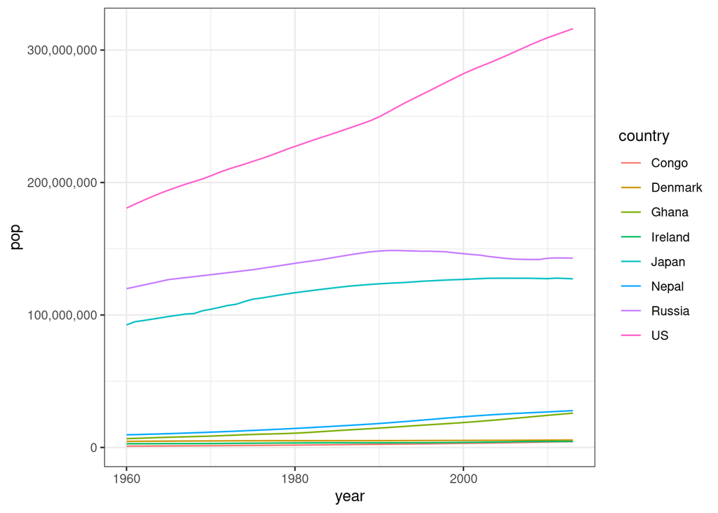

```r
ggplot(popstat, aes(year, pop, color = country)) +
  geom_line() +
  scale_y_continuous(labels = scales::comma_format())
```